# Berechnung

Katharina Wagner

9 Dezember 2019

# Packages, Libraries und Daten laden:

```r
#install.packages("haven")
#install.packages("sjlabelled")
knitr::opts_chunk$set(echo = TRUE)
library(tidyverse)
library(haven)
library(sjlabelled)
library(knitr)
options(scipen = 1, digits = 3)

path = file.path("data/survey.sav")
df = read_sav(path)
```

# Daten bereinigen

```r
#df %>% filter(Status == 0)
df <- df[c(-1:-10),c(-1:-4, -8:-16)]
df <- df %>% filter(Finished != "0")
df <- df[,c(-1,-3,-4)]
df <- arrange(df,stimuli1_n_items_1)
df <- df[,c(-20:-26, -35:-42, -48:-52, -130:-136, -145:-152, -158:-162, -171:-178)]

df <- df %>% mutate(FL_9_DO_Beitr_geNeutral = replace(FL_9_DO_Beitr_geNeutral, FL_9_DO_Beitr_geNeutral == 1, "N"))


df <- df %>% mutate(FL_9_DO_Beitr_geEmotional = replace(FL_9_DO_Beitr_geEmotional, FL_9_DO_Beitr_geEmotional == "1", "E"))

#df <- df %>% combine(df$FL_9_DO_Beitr_geNeutral,df$FL_9_DO_Beitr_geEmotional)

#df <- df %>% unite("group_stimuli", FL_9_DO_Beitr_geEmotional:FL_9_DO_Beitr_geNeutral, na.rm = FALSE)

#mutate(coalesce()
#df %>% mutate(neu = coalesce())
```

# Wir haben drei Gruppen:

Social Media-Nutzer und Nicht-Nutzer Utopia-Kenner und Nicht-Kenner Mindset-Emotional vs Mindset-Neutral

# Variablen:

mind1_items1_1 bis mind1_items3_5 (Spalte 13-52) : Persönliche Einstellung 1

*Was bedeuten die DO-Variablen?(mindX_itemX_DO_X) df3 mit DO-Variablen, df ohne DO-Variablen*

Beiträge Neutral (Spalte 53-87): stimuli1_n_items_1 bis stimuli5_n_items_4 Beiträge Neutral (Social Media Abfrage): stimuli1_n_socmed_1 bis stimuli5_n_socmed_3

Beiträge Emotional (Spalte 88-122): stimuli1_e_items_1 bis stimuli5_e_items_4 Beiträge Emotional (Social Media Abfrage): stimuli1_e_socmed_1 bis stimuli5_e_socmed_3

Persönliche Einstellung 2 (Spalte 123-162): mind2_items1_1 bis mind2_items3_5

Verhalten (Spalte 163-178): behavior_items_1 bis behavior_items_8

# Fragen

Wie benennt man die NAs in der Spalte zu E um und wie benennt man Spalte zu group_mind um? Sollten wir auch noch group_socmed und group_utopia hinzufügen? Evtl. Zeile 131 und 133 noch rauslöschen?

## Deskriptive Statistik

|  | vars | n | mean | sd | median | trimmed | mad | min | max | range | skew | kurtosis | se |
| --- | --- | --- | --- | --- | --- | --- | --- | --- | --- | --- | --- | --- | --- |
| Duration_*in_seconds* | 1 | 107 | 7363.33 | 47768.792 | 657.0 | 695.17 | 214.977 | 268 | 432030 | 431762 | 7.709 | 61.053 | 4617.983 |
| age | 2 | 107 | 28.62 | 9.726 | 27.0 | 26.64 | 4.448 | 19 | 68 | 49 | 2.475 | 6.042 | 0.940 |
| gender | 3 | 107 | 1.62 | 0.488 | 2.0 | 1.64 | 0.000 | 1 | 2 | 1 | -0.474 | -1.792 | 0.047 |
| language* | 4 | 107 | NaN | NA | NA | NaN | NA | Inf | -Inf | -Inf | NA | NA | NA |
| education | 5 | 107 | 4.83 | 1.225 | 5.0 | 4.94 | 1.483 | 1 | 7 | 6 | -0.719 | 0.457 | 0.118 |
| job* | 6 | 107 | NaN | NA | NA | NaN | NA | Inf | -Inf | -Inf | NA | NA | NA |
| socialmedia | 7 | 107 | 1.05 | 0.212 | 1.0 | 1.00 | 0.000 | 1 | 2 | 1 | 4.235 | 16.087 | 0.020 |
| use_socialmedia_1 | 8 | 101 | 4.24 | 1.297 | 4.0 | 4.37 | 1.483 | 1 | 6 | 5 | -0.768 | 0.319 | 0.129 |
| use_socialmedia_2 | 9 | 100 | 2.33 | 1.101 | 2.0 | 2.24 | 1.483 | 1 | 6 | 5 | 0.587 | 0.069 | 0.110 |
| use_socialmedia_3 | 10 | 100 | 2.19 | 1.316 | 2.0 | 2.05 | 1.483 | 1 | 6 | 5 | 0.679 | -0.730 | 0.132 |
| utopia | 11 | 107 | 1.87 | 0.339 | 2.0 | 1.95 | 0.000 | 1 | 2 | 1 | -2.159 | 2.686 | 0.033 |
| use_utopia_1 | 12 | 14 | 2.21 | 1.369 | 2.0 | 2.08 | 1.483 | 1 | 5 | 4 | 0.646 | -1.080 | 0.366 |
| mind1_items1_1 | 13 | 107 | 1.41 | 0.776 | 1.0 | 1.23 | 0.000 | 1 | 4 | 3 | 1.911 | 2.879 | 0.075 |
| mind1_items1_2 | 14 | 107 | 1.61 | 0.998 | 1.0 | 1.41 | 0.000 | 1 | 6 | 5 | 1.738 | 2.885 | 0.096 |
| mind1_items1_3 | 15 | 107 | 5.50 | 0.905 | 6.0 | 5.70 | 0.000 | 1 | 6 | 5 | -2.410 | 6.839 | 0.087 |
| mind1_items1_4 | 16 | 107 | 5.86 | 0.349 | 6.0 | 5.94 | 0.000 | 5 | 6 | 1 | -2.044 | 2.198 | 0.034 |
| mind1_items1_5 | 17 | 107 | 4.24 | 1.324 | 5.0 | 4.32 | 1.483 | 1 | 6 | 5 | -0.447 | -0.753 | 0.128 |
| mind1_items1_6 | 18 | 107 | 5.09 | 1.077 | 5.0 | 5.26 | 1.483 | 1 | 6 | 5 | -1.260 | 1.414 | 0.104 |
| mind1_items1_7 | 19 | 107 | 5.36 | 0.873 | 6.0 | 5.52 | 0.000 | 1 | 6 | 5 | -1.861 | 5.012 | 0.084 |
| mind1_items2_1 | 20 | 107 | 4.33 | 1.426 | 4.0 | 4.46 | 1.483 | 1 | 6 | 5 | -0.465 | -0.586 | 0.138 |
| mind1_items2_2 | 21 | 107 | 4.59 | 1.181 | 5.0 | 4.71 | 1.483 | 1 | 6 | 5 | -1.078 | 1.206 | 0.114 |
| mind1_items2_3 | 22 | 107 | 4.99 | 0.906 | 5.0 | 5.07 | 1.483 | 2 | 6 | 4 | -0.661 | 0.011 | 0.088 |
| mind1_items2_4 | 23 | 107 | 4.39 | 1.139 | 5.0 | 4.45 | 1.483 | 1 | 6 | 5 | -0.572 | 0.056 | 0.110 |
| mind1_items2_5 | 24 | 107 | 2.06 | 1.215 | 2.0 | 1.86 | 1.483 | 1 | 6 | 5 | 1.407 | 1.723 | 0.117 |
| mind1_items2_6 | 25 | 107 | 4.78 | 1.003 | 5.0 | 4.86 | 1.483 | 2 | 6 | 4 | -0.436 | -0.438 | 0.097 |
| mind1_items2_7 | 26 | 107 | 4.27 | 1.477 | 5.0 | 4.40 | 1.483 | 1 | 6 | 5 | -0.642 | -0.562 | 0.143 |
| mind1_items2_8 | 27 | 107 | 4.33 | 1.379 | 4.0 | 4.46 | 1.483 | 1 | 6 | 5 | -0.615 | -0.249 | 0.133 |
| mind1_items3_1 | 28 | 107 | 3.97 | 1.384 | 4.0 | 4.07 | 1.483 | 1 | 6 | 5 | -0.543 | -0.264 | 0.134 |
| mind1_items3_2 | 29 | 107 | 2.35 | 1.381 | 2.0 | 2.16 | 1.483 | 1 | 6 | 5 | 0.861 | 0.011 | 0.134 |
| mind1_items3_3 | 30 | 107 | 5.12 | 1.171 | 6.0 | 5.33 | 0.000 | 1 | 6 | 5 | -1.560 | 2.365 | 0.113 |

[output cut: 103 more lines]

## Skalen berechnen

### Faktorenanalyse

```r
library(psych)
faktorenanalyse <- df %>%  select(starts_with("mind1_items"))

#Korrelationstabelle
r <- lowerCor(faktorenanalyse)
```

```
##                m1_1_1 m1_1_2 m1_1_3 m1_1_4 m1_1_5 m1_1_6 m1_1_7 m1_2_1
## mind1_items1_1  1.00
## mind1_items1_2  0.41   1.00
## mind1_items1_3 -0.29  -0.18   1.00
## mind1_items1_4 -0.20  -0.43   0.31   1.00
## mind1_items1_5 -0.27  -0.22   0.28   0.22   1.00
## mind1_items1_6 -0.35  -0.20   0.27   0.11   0.43   1.00
## mind1_items1_7 -0.21  -0.18   0.32   0.26   0.35   0.36   1.00
## mind1_items2_1 -0.04  -0.24   0.24   0.11   0.10   0.27   0.32   1.00
## mind1_items2_2 -0.28  -0.22   0.15   0.25   0.35   0.22   0.47   0.15
## mind1_items2_3 -0.30  -0.21   0.19   0.23   0.36   0.41   0.45   0.33
## mind1_items2_4 -0.39  -0.40   0.24   0.21   0.39   0.36   0.42   0.19
## mind1_items2_5  0.04   0.02  -0.09  -0.18  -0.03  -0.08  -0.10  -0.08
## mind1_items2_6 -0.29  -0.15   0.36   0.15   0.43   0.48   0.37   0.20
## mind1_items2_7 -0.18  -0.10   0.25   0.02   0.55   0.30   0.30   0.32
## mind1_items2_8 -0.33  -0.28   0.14   0.19   0.33   0.20   0.26   0.42
## mind1_items3_1 -0.16   0.01   0.15   0.01   0.44   0.22   0.22   0.34
## mind1_items3_2  0.21   0.35  -0.15  -0.15  -0.19  -0.19  -0.27  -0.40
## mind1_items3_3 -0.23  -0.38   0.31   0.18   0.31   0.14   0.33   0.12
## mind1_items3_4 -0.33  -0.25   0.19   0.16   0.23   0.28   0.35   0.26
## mind1_items3_5  0.04   0.20  -0.11  -0.08  -0.24  -0.14  -0.21  -0.23
##                m1_2_2 m1_2_3
## mind1_items1_1
## mind1_items1_2
## mind1_items1_3
## mind1_items1_4
## mind1_items1_5
## mind1_items1_6
## mind1_items1_7
## mind1_items2_1
## mind1_items2_2  1.00
## mind1_items2_3  0.43   1.00
## mind1_items2_4  0.45   0.41
## mind1_items2_5  0.03  -0.02
## mind1_items2_6  0.30   0.35
## mind1_items2_7  0.42   0.43
## mind1_items2_8  0.43   0.40
## mind1_items3_1  0.29   0.26
## mind1_items3_2 -0.29  -0.22
## mind1_items3_3  0.35   0.12
```

[output cut: 9 more lines]

```
## mind1_items3_2 -0.35   0.13  -0.26  -0.42  -0.35  -0.41   1.00
## mind1_items3_3  0.37  -0.13   0.21   0.23   0.27   0.07  -0.20   1.00
## mind1_items3_4  0.28  -0.19   0.24   0.27   0.29   0.31  -0.39   0.28
## mind1_items3_5 -0.29  -0.11  -0.22  -0.41  -0.42  -0.24   0.29  -0.18
##                m1_3_4 m1_3_5
## mind1_items2_4
## mind1_items2_5
## mind1_items2_6
## mind1_items2_7
## mind1_items2_8
## mind1_items3_1
## mind1_items3_2
## mind1_items3_3
## mind1_items3_4  1.00
## mind1_items3_5 -0.14   1.00
```

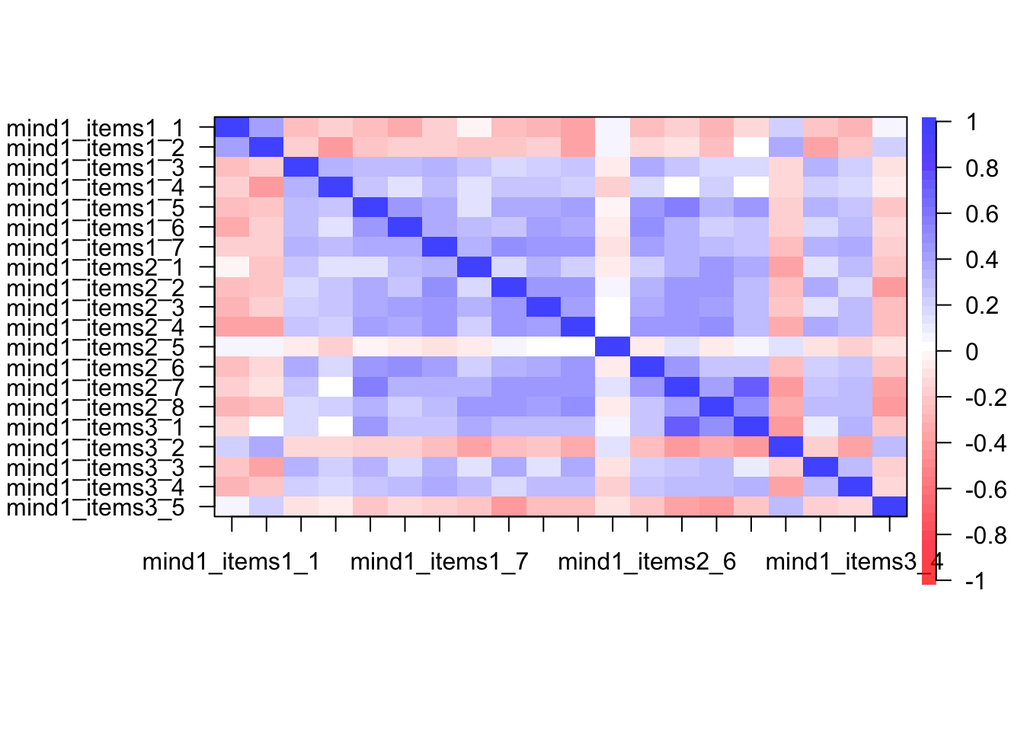

```r
#Korrelationsmatrix
corPlot(r)
```

```r
#Principal-Component-Analysis
pca(r,nfactors = 5)
```

```
## Principal Components Analysis
## Call: principal(r = r, nfactors = nfactors, residuals = residuals,
##     rotate = rotate, n.obs = n.obs, covar = covar, scores = scores,
##     missing = missing, impute = impute, oblique.scores = oblique.scores,
##     method = method)
## Standardized loadings (pattern matrix) based upon correlation matrix
##                  RC1   RC3   RC5   RC2   RC4   h2   u2 com
## mind1_items1_1 -0.40 -0.15 -0.67  0.18  0.14 0.68 0.32 2.0
## mind1_items1_2  0.01 -0.13 -0.80 -0.15 -0.13 0.70 0.30 1.2
## mind1_items1_3  0.51 -0.01  0.19  0.06  0.32 0.41 0.59 2.1
## mind1_items1_4  0.12 -0.14  0.46  0.27  0.45 0.52 0.48 3.0
## mind1_items1_5  0.66  0.20  0.18  0.20 -0.15 0.56 0.44 1.7
## mind1_items1_6  0.73  0.16  0.11 -0.05  0.09 0.58 0.42 1.2
## mind1_items1_7  0.52  0.09  0.10  0.41  0.38 0.60 0.40 3.0
## mind1_items2_1  0.09  0.58 -0.07  0.25  0.45 0.62 0.38 2.4
## mind1_items2_2  0.29  0.11  0.26  0.69 -0.05 0.64 0.36 1.7
## mind1_items2_3  0.50  0.20  0.09  0.40  0.13 0.48 0.52 2.5
## mind1_items2_4  0.42  0.23  0.48  0.33 -0.10 0.58 0.42 3.4
## mind1_items2_5 -0.05 -0.10 -0.05  0.22 -0.67 0.51 0.49 1.3
## mind1_items2_6  0.73  0.12  0.10  0.13  0.05 0.57 0.43 1.2
## mind1_items2_7  0.48  0.58 -0.04  0.36 -0.24 0.76 0.24 3.1
## mind1_items2_8  0.11  0.55  0.30  0.42  0.02 0.58 0.42 2.6
## mind1_items3_1  0.31  0.75 -0.10  0.15 -0.20 0.73 0.27 1.7
## mind1_items3_2 -0.04 -0.69 -0.28 -0.14 -0.17 0.61 0.39 1.6
## mind1_items3_3  0.18  0.04  0.53  0.26  0.13 0.40 0.60 1.9
## mind1_items3_4  0.25  0.54  0.33 -0.16  0.25 0.55 0.45 2.9
## mind1_items3_5 -0.03 -0.28 -0.08 -0.69  0.11 0.57 0.43 1.4
##
##                        RC1  RC3  RC5  RC2  RC4
## SS loadings           3.16 2.65 2.29 2.13 1.43
## Proportion Var        0.16 0.13 0.11 0.11 0.07
## Cumulative Var        0.16 0.29 0.40 0.51 0.58
## Proportion Explained  0.27 0.23 0.20 0.18 0.12
## Cumulative Proportion 0.27 0.50 0.69 0.88 1.00
##
## Mean item complexity =  2.1
## Test of the hypothesis that 5 components are sufficient.
##
## The root mean square of the residuals (RMSR) is  0.07
##
## Fit based upon off diagonal values = 0.94
```

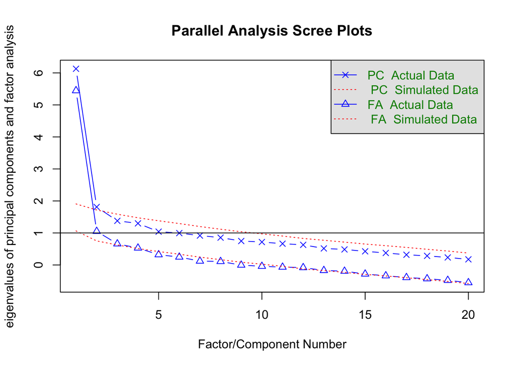

```
## Parallel analysis suggests that the number of factors =  2  and the number of components =  1
```

```r
#oder genau: pca(faktorenanalyse, covar = F)

#Faktorenbestimmung mit paralleler Analyse
fa.parallel(r)
```